# Statistical Analysis of Fire Incidents in the City of Greensboro, NC

Danielle Mirzaeian, Nahom Fisseha

Faculty Research Mentor Dr. Sayed Mostafa

Graduate Research Assistant Mentor Chinedu Jude Nzekwe

2022-06-22

## Abstract

The research in this report examines twelve years of reported fire incidents in Greensboro, NC to further analyze how fire service response time is affected as well as how fire service response time affects the rate of total loss in household fires. Additionally, this report will provide a variety of forecasting models in order to predict the future in regards to reported fire incidents. To produce sufficient results a variety of statistical analysis approaches have been accomplished. We have visualized the data (univariate , bivariate, time series), forecasted the data (TBATS, ARIMA, Holtwinters), and built linear regression and random forest models in order to fully conquer the research questions at task. In result, we were able to identify what factors hold most significance in relation to response time as well as depict to what extent response time affects total loss. In addition we produced multiple forecasting models in order to accurately predict the future of reported fire incidents in Greensboro, NC.

## Introduction

Many calls are made to fire departments all the time. Whether it is a false alarm or not, it is important for first responders to take care of fire incidents as soon as possible. Therefore it is important to look at data about different fire incidents and see how the response time can be improved for all kinds of situations.

There are all kinds of fire incidents, some not even about fires. For example someone could be having a stroke and the local fire department was called to take action on the situation. If the incident is a fire, it could be at all kinds of different properties. Some different properties are small houses, apartment buildings, and highways. The fire could vary in size, like the wildfires in California.

No matter the type of fire incident. It is vital that first responders attend to the situation quickly. Now, there can be some factors that can affect the response time of the first responders. Some of those factors are the location, the type of property, and the type of the incident. From this project we want to explore which factors from the data have a significant affect on the response time of the fire department. By learning about these factors, the fire department could use this information to work on decreasing their response time.

For more than ten years, the city of Greensboro, NC has been collecting data on fire incidents in their area. Some of this data includes the date of the incident, the response time, the location, and the type of property. Yet, take note when looking at the data that it goes from July 1, 2010, to May 31, 2022. So for the years 2010 and 2022, only data for about half of those years was collected.

For this project we will be visualizing the fire incidents in Greensboro, NC. Our research questions are 1) What factors affect the response time to fire incidents? 2) How to improve the response time? 3) How does response time by fire emergency services affect the rate of total loss and civilian injuries? 4)Can we build models to forecast the number of fire incidents in certain areas of Greensboro based on the data from 2010 to 2022? 5) What Dynamic models can we make for forecasting fire incidents?

## Related Literature

Prior to beginning this study we sought to obtain as much knowledge from previous similar reports as possible. In this process we were able to acquire multiple different reports from a variety of similar topics ranging from observing response time to forecasting mass fires . With this, each report had its own distinct way of coming to a solution.

To begin our review of previous reports we first analyzed several reports regarding the observation of response time. In a report that analyzed fire service response time by Aleisa and Savsar (2014), they wanted to create a discrete event simulation that reduces the response time to fire incidents to below five minutes. It was concluded that with the introduction of centralized systems and navigation technology response time was able to be reduced by 32%. Buffington and Ezekoye (2018) did a research project about analyzing the relationship between fire service response times and fire outcomes. While using the NFIRS dataset they were able to conclude that on average, increasing response times are linked to increasing monetary losses at a rate of about 3000 USD per minute for the interval between 3-13min. Similarly, Neil Challands (2010) also wrote a paper analyzing the same relationship. He used plots of various types to analyze the different types of fires and their relationship to response time. He found that response time significantly affects the amount of structural damage. In another report written by KC and Corcoran (2017) they looked at how spatial patterns of residential fire incidents affect response time and what factors explain those spatial patterns. In their modeling they looked at 12 variables. Some of those are Winter(Incidents during the winter), socioeconomic disadvantage, street connectivity, and fire station distance. They found that response time tends to increase from factors like winter weather, places with high numbers of children and low socioeconomic households. Most importantly, their results showed that low street connectivity had the biggest impact on response time. In addition, some students from Vanderbilt University (2017) wanted to solve the problem of having efficient response time for highly populated areas. They approached this by creating a non-linear mathematical program that optimized the expected incident coverage and proposing an algorithmic framework to solve the issue.

We then continued to review previous reports in regards to forecasting fires. Similar to our approach we found a group of students from the Data Science program at the University of San Francisco (2019) who were able to use linear regression in machine learning to predict and analyze response times for the San Francisco Fire Department. Another report written by Li, Zhang, and Fu (2022) they wanted to learn how to use drones to monitor and eliminate forest fire incidents in Victoria. One thing they did in this paper that is related to a part of our research was building a forecasting model that predicted the following 10 years of forest fires in Australia through K-means clustering algorithms and time series forecasting (SARIMA). With that information from the time series forecasting, they estimated the increase in the expense of one drone over ten years.

Although multiple studies have sought to capture the analytics behind many different aspects in regards to fire incidents, not many have gone completely in-depth in terms of covering fully what factors can affect a given fire department in terms of fire service response time. In this report we aim to completely cover all given factors that may affect fire service response time and how response time affects the rate of total loss in Greensboro, NC. Additionally, to help the Greensboro Fire Department be better prepared for dealing with future fire incidents in the city, we will build a variety of models to forecast the future daily and weekly number of fire incidents in the city.

## Data, Methods, and Analysis

### Data

For this analysis, we utilized public data from the Greensboro Fire Department. This data set accounts for all reported fire incidents in the city of Greensboro and updates itself continuously. Although, we noticed there were some missing values in the data. So we did a map to check the percentage of missing values and it ended being about 14 percent for the whole data set. To further cater towards our research we filtered the data set in two areas; the date (from July 1, 2010 to May 31st, 2022) and the Property Use (“1-2 family dwelling”). In addition to this we converted ResponseTime to seconds. The initial data set can be found at this website link:https://data.greensboro-nc.gov/datasets/greensboro-fire-incidents/explore

### Methods

#### Exploratory Data Analysis

The first step in our research project was exploratory data analysis. During this process we investigated the data looking for patterns and outliers. This was carried out by making various graphical representations of the data.

#### Univariate Explorations

Data Visualizations consisting of one variable

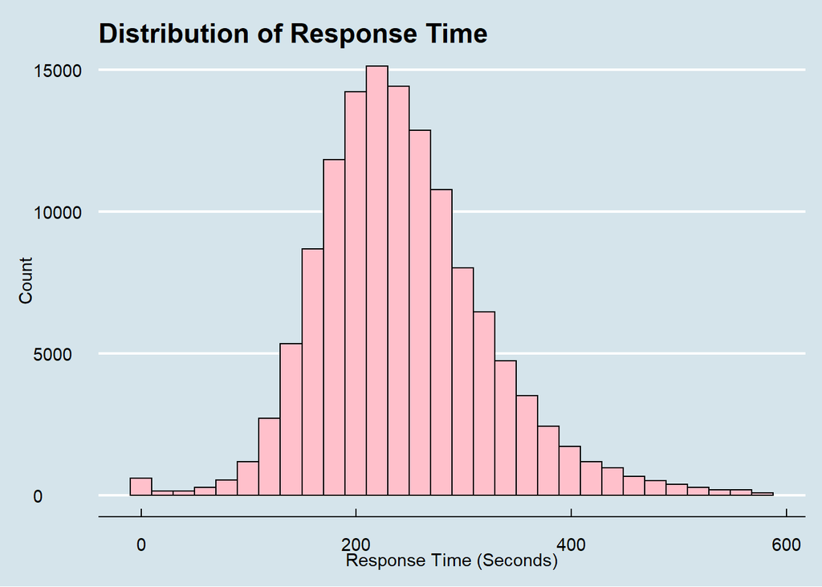

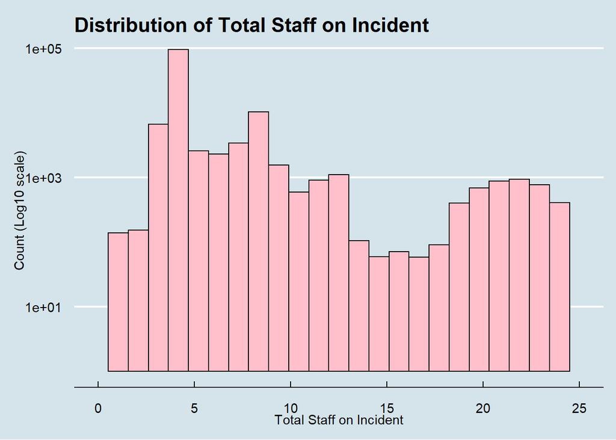

From the histogram above, we can visually see the distribution of the amount of staff members reported towards a given incident. It is important to note that the Y-axis on this graph has been scaled. Overall, the great majority of total stall on incident is 4.

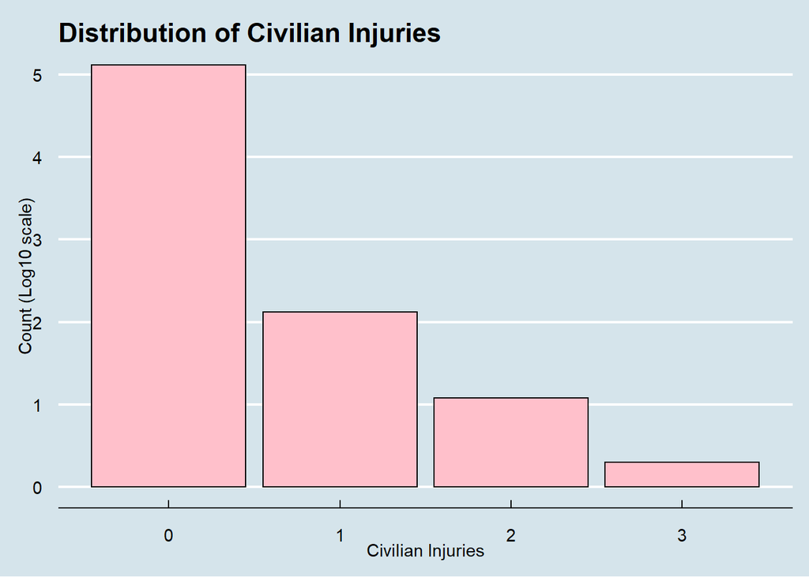

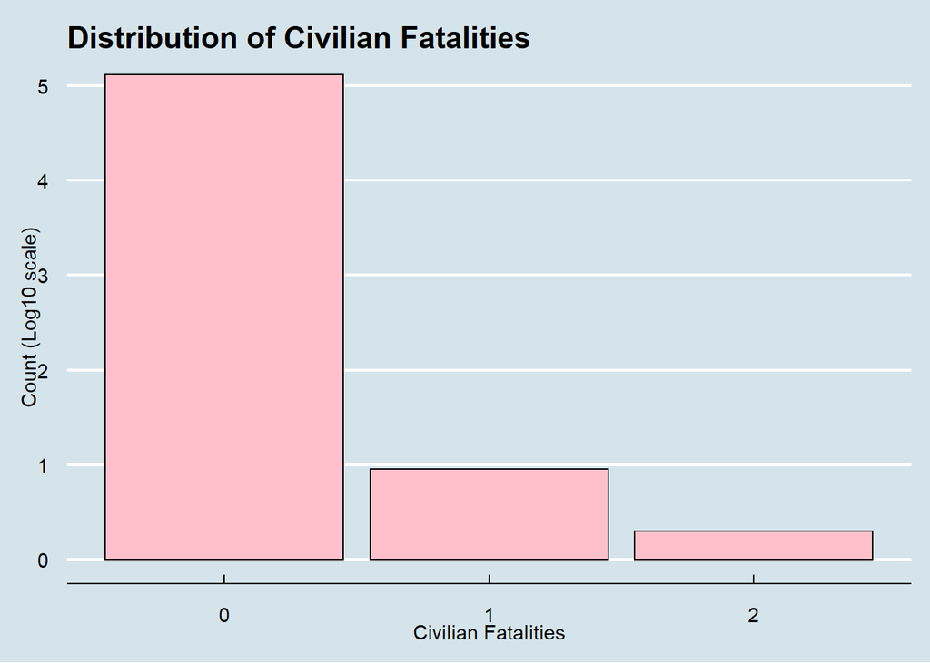

For the graph above, we can identify that there has only been a couple incidents in which fatalities have been reported in regards to civilians. It is important to note that the Y-axis on this graph has been scaled. Overall, the great majority of civilian fatalities is 0.

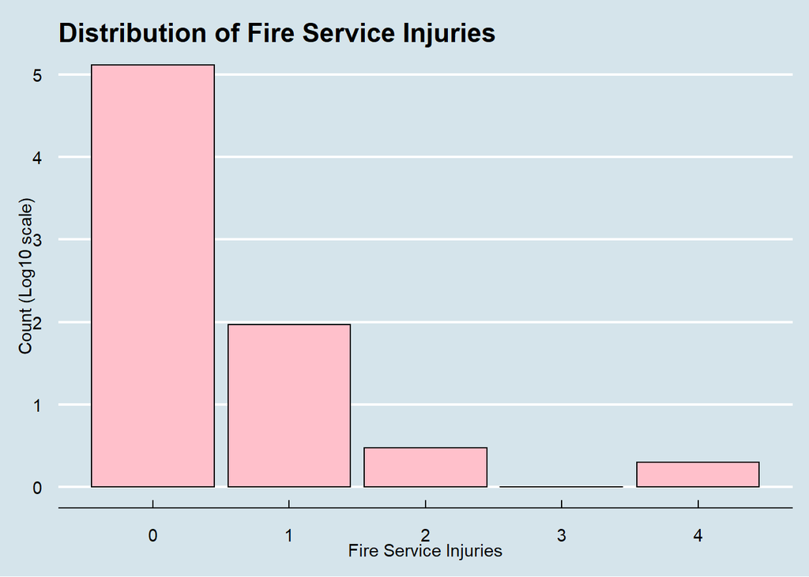

For the graph above, we can identify that there has only been a handful of incidents in which injuries have been reported in regards to fire service respondents. It is important to note that the Y-axis on this graph has been scaled. Overall, the great majority of fire service injuries is 0.

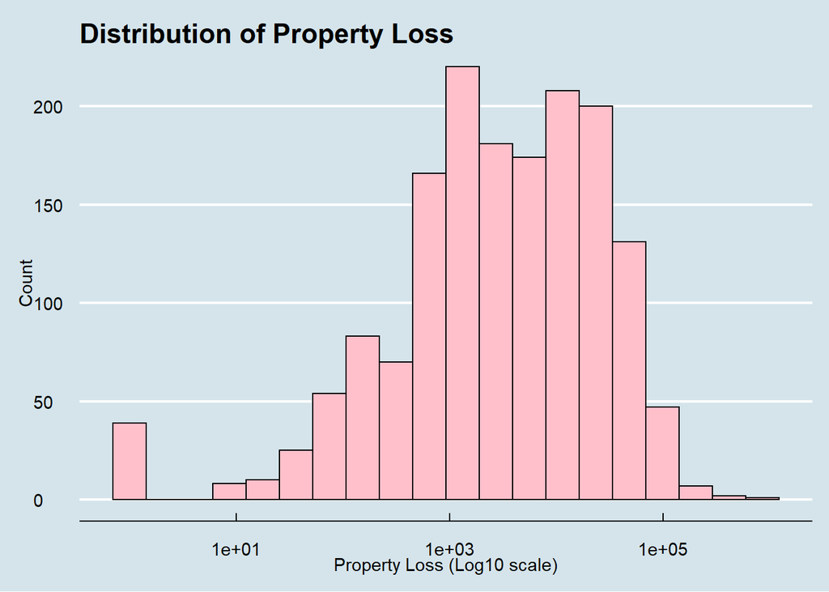

The histogram above displays the amount of property loss across the amount of incidents reported.

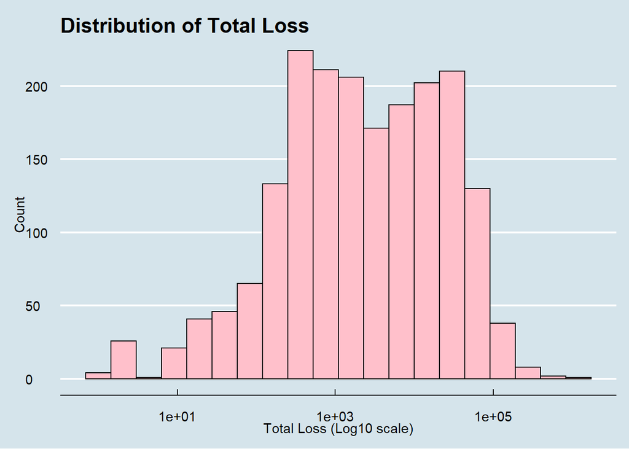

The histogram above displays the amount of total loss (property + content) across the amount of incidents reported.

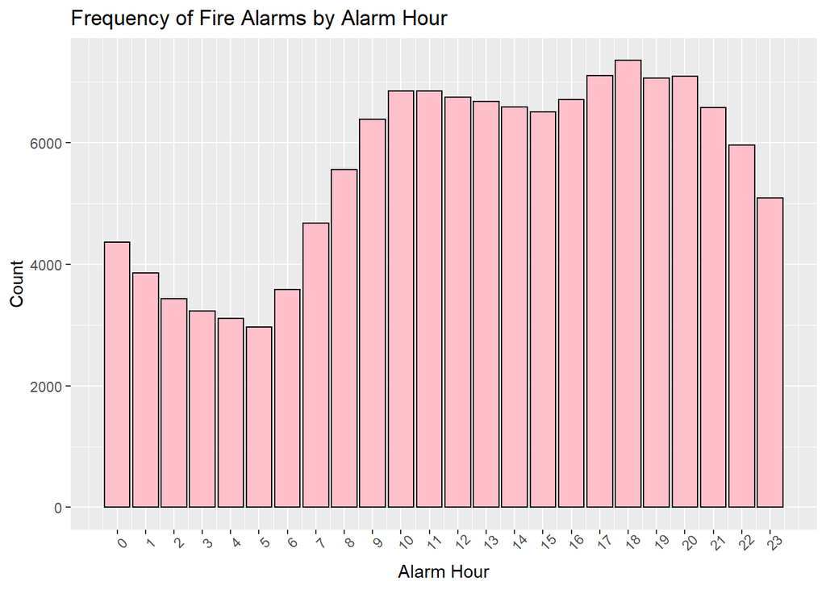

From this bar graph, it can be seen that the frequency of calls to the fire stations are less during the middle of the night and increase as people start waking up.

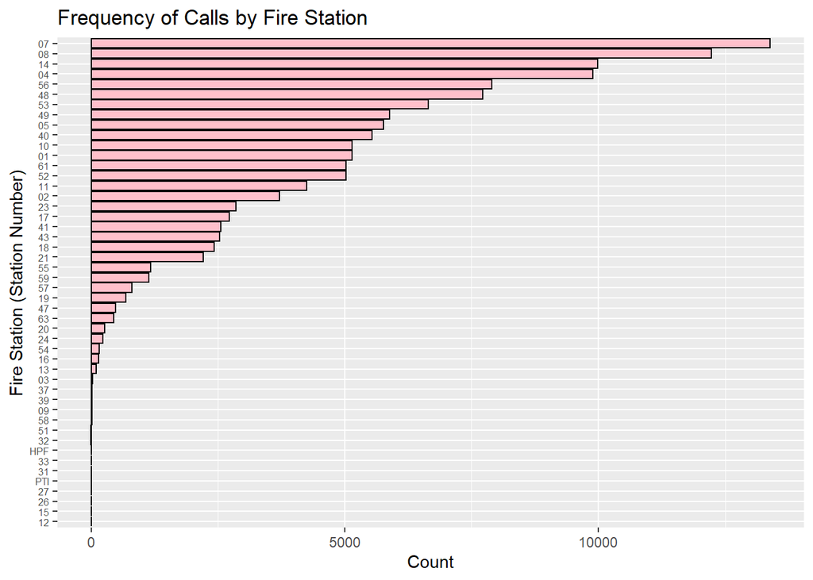

For this graph, we wanted to find out which fire stations got the most calls. Note that the calls counted are from July 1, 2010 to Jun 1, 2022. From the results we can tell that the top five fire stations that got the most calls over ten years in Greensboro NC, was 7, 8, 14, 4, and 56.

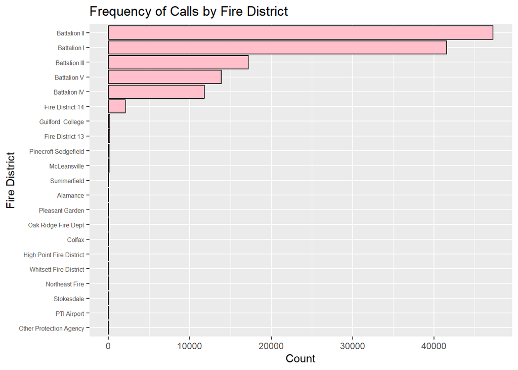

For this bar plot, we wanted to find out which fire districts got the most calls in Greensboro, NC over ten years. The fire districts consist of a few fire stations. The most popular fire districts from this bar plot from greatest to least were Battalion II, Battalion I and Battalion III.

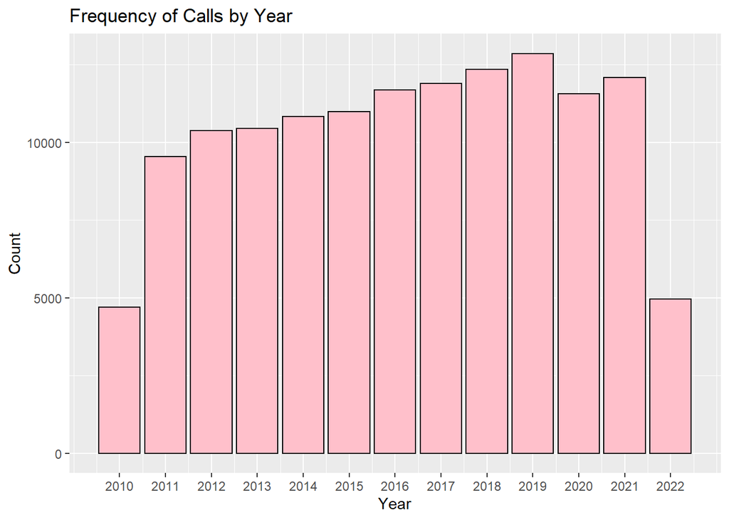

From this graph, we wanted to learn if there were some years that had a significant difference in number of phone calls to the fire stations in Greensboro, NC. By looking at those differences we could explore how response time varied between years that were busier than others. Note from this graph, that only half of the data was collected for the years 2010 and 2022, so those bars will be obviously lower than the bars of other years displayed in the graph.

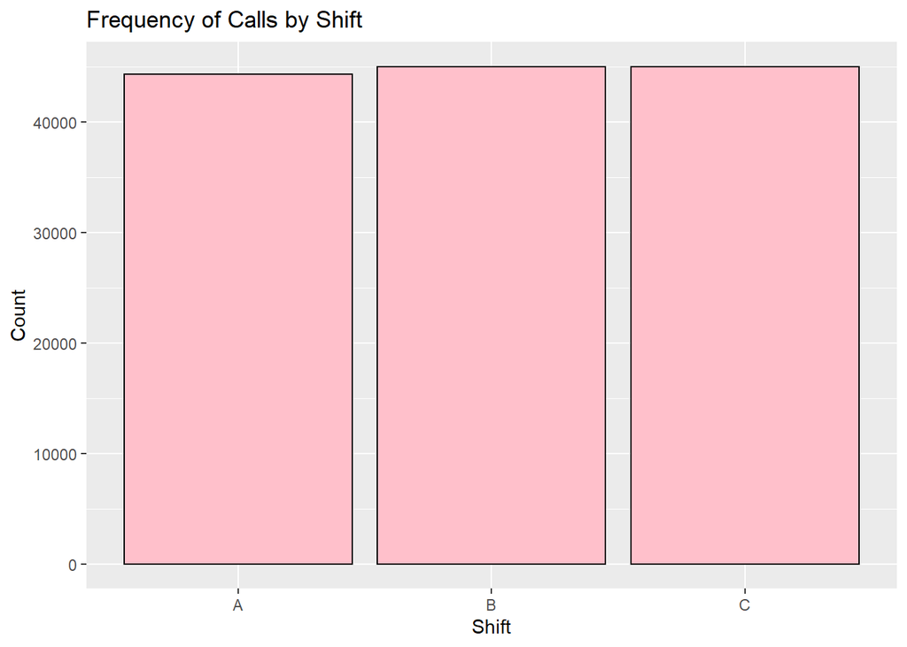

This visual was created to look at if the number of calls to the fire station would vary depending on which shift was currently working. For this data, there were three shifts, A, B, and C. From the results, it can be seen that there is no obvious difference in the frequency of the calls to the fire station on different work shifts.

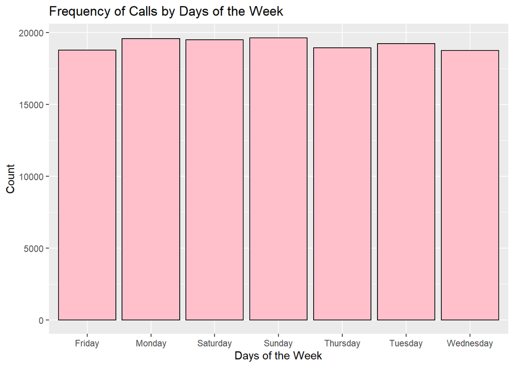

From this bar graph, it can be seen that the frequency of calls to the fire station over ten years ended up being about the same between each day of the week with no obvious differences.

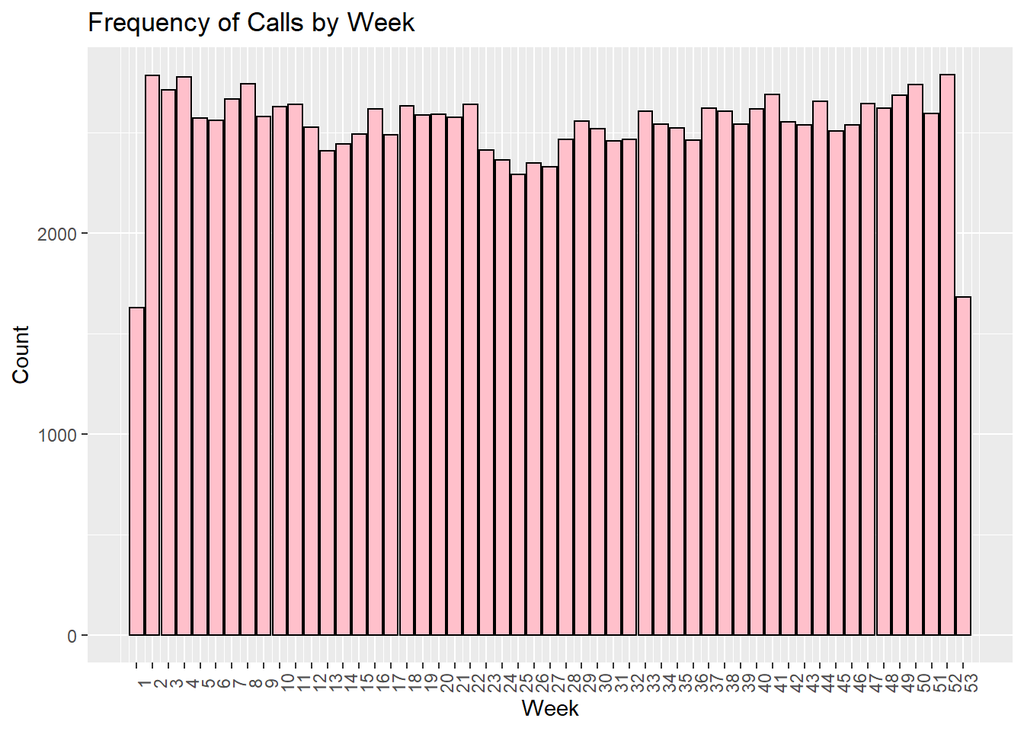

From the bar plot above, it is shown that the first week and the last week of the year typically had fewer calls to the fire station compared to other weeks in the year. This graph had a little more variability in frequency in calls. For example, the dip in the middle of the bar plot. This plot helps us to look at the busier times in the data and compare the response times.

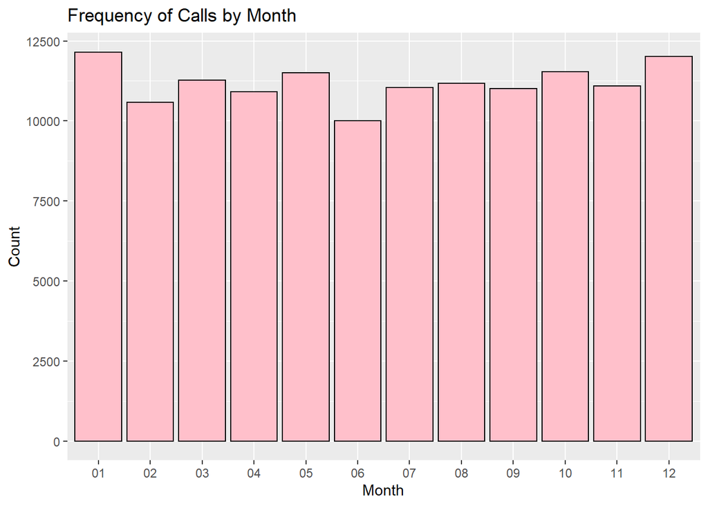

This visual was used to look further into if there was a higher frequency of calls to fire stations in certain parts of the year. From the results, June and February seem to have the lowest frequency of calls, while January and December have the highest frequency of calls. With this knowledge we can look at how response time varied with those months.

#### Bivariate Explorations

Data Visualizations of a given variable vs response time

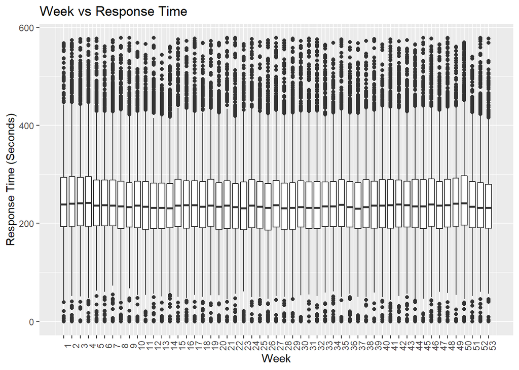

From this box plot, we wanted to see if certain weeks would have notable differences in response time. Looking at the results, there does not seem to be much variation. Therefore, the weeks in the year might not have a significant impact on response time.

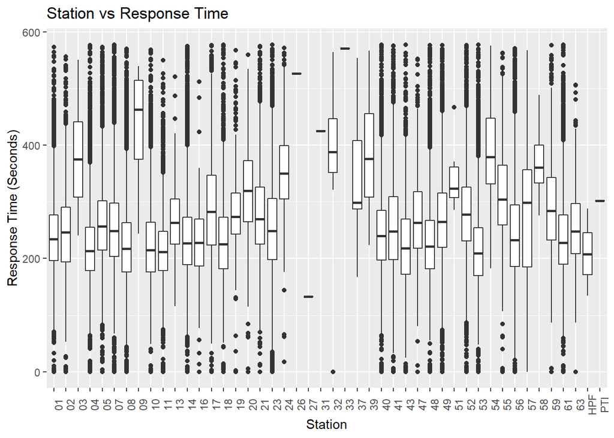

The box plot above shows that there is a lot of variability in response time depending on which station responded to the call. By looking at these results, we can explore and question why different fire stations have such big contrasts in response time.

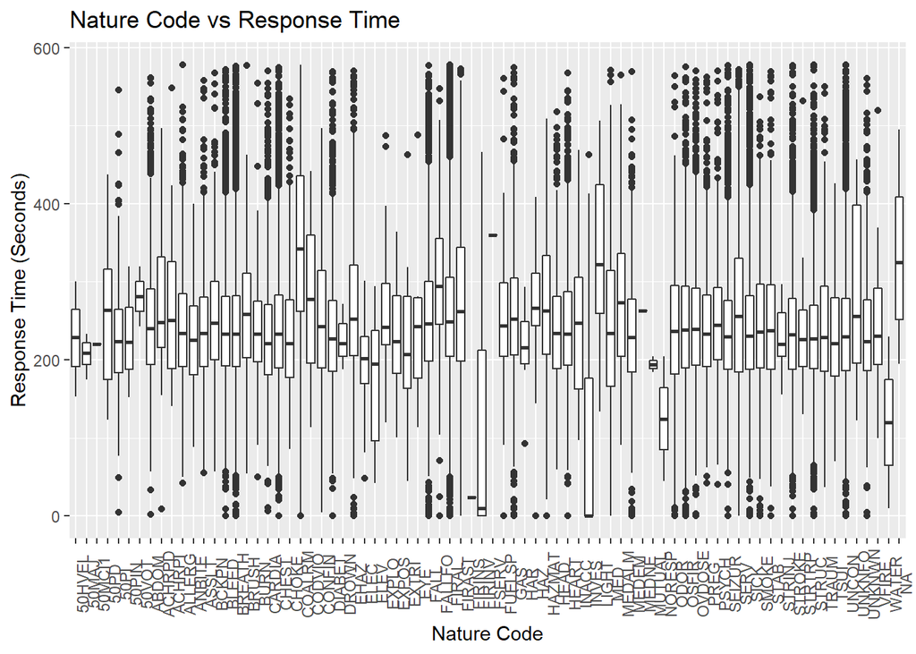

For this graph above, we looked at nature code and how it affects response time. Nature code represents the nature of the fire incident, whether it was a fire or someone having a stroke. As shown by the graph, there is a lot of variability in response time depending on the nature of the fire incident.

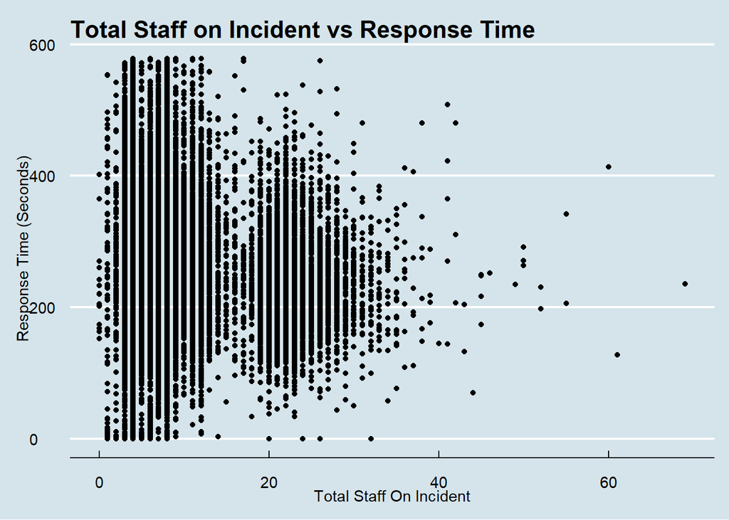

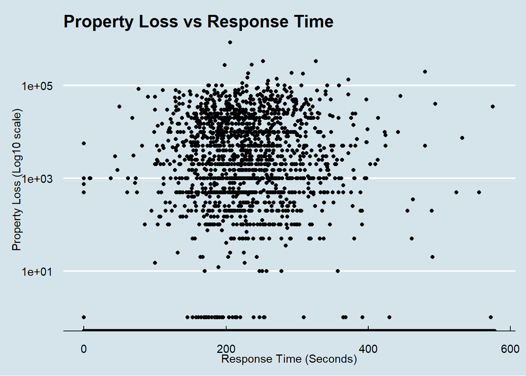

From the scatter plot above, we wanted to visualize the relationship between response time and property loss. Through this we were able to identify a very slight correlation between the two. The majority of the higher property loss values fall between 100 and 400 seconds

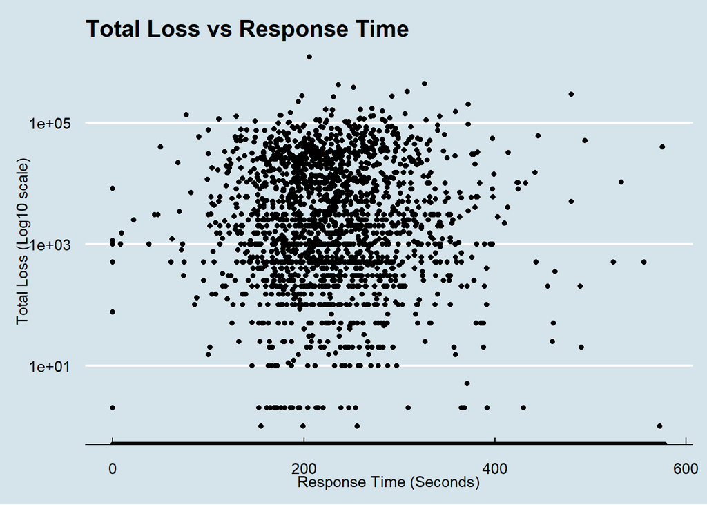

From the scatter plot above, we wanted to visualize the relationship between response time and total loss. Through this we were able to identify a very slight correlation between the two. Similar to property loss, the majority of the higher total loss values fall between 100 and 400 seconds.

Below, the box and violin plots had similar results to the bar graphs presented earlier. Each graph will summarize briefly what have seen before.

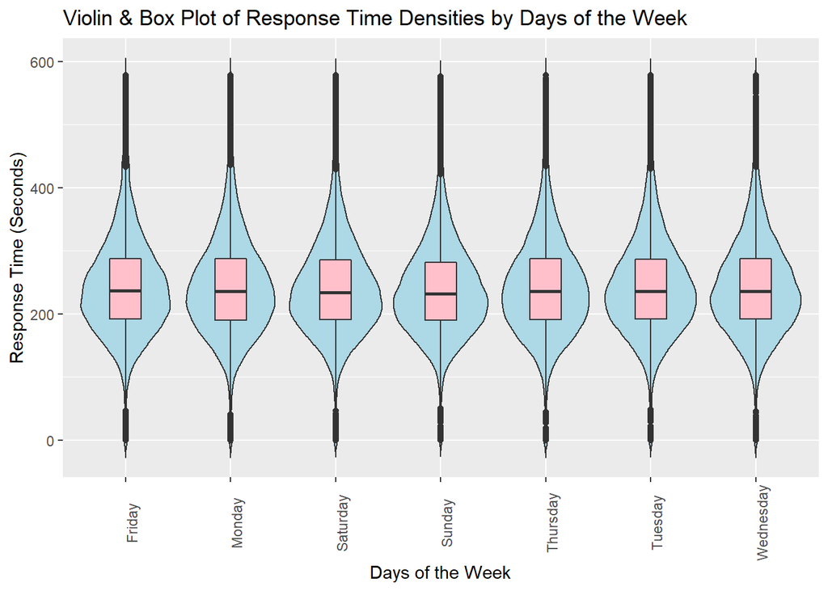

For this violin and box plot, it can be seen that there is very little difference in response time between the days of the week.

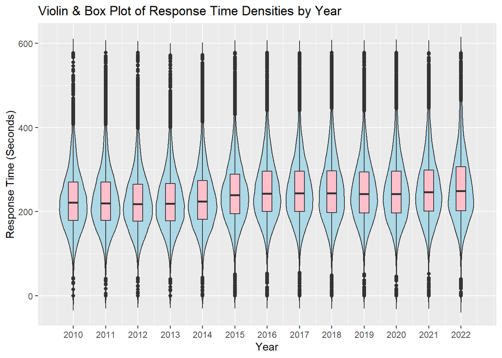

From the plot above there is a slight increase in the average response time after the year 2013 and it continues to stay the same or slightly increase more.

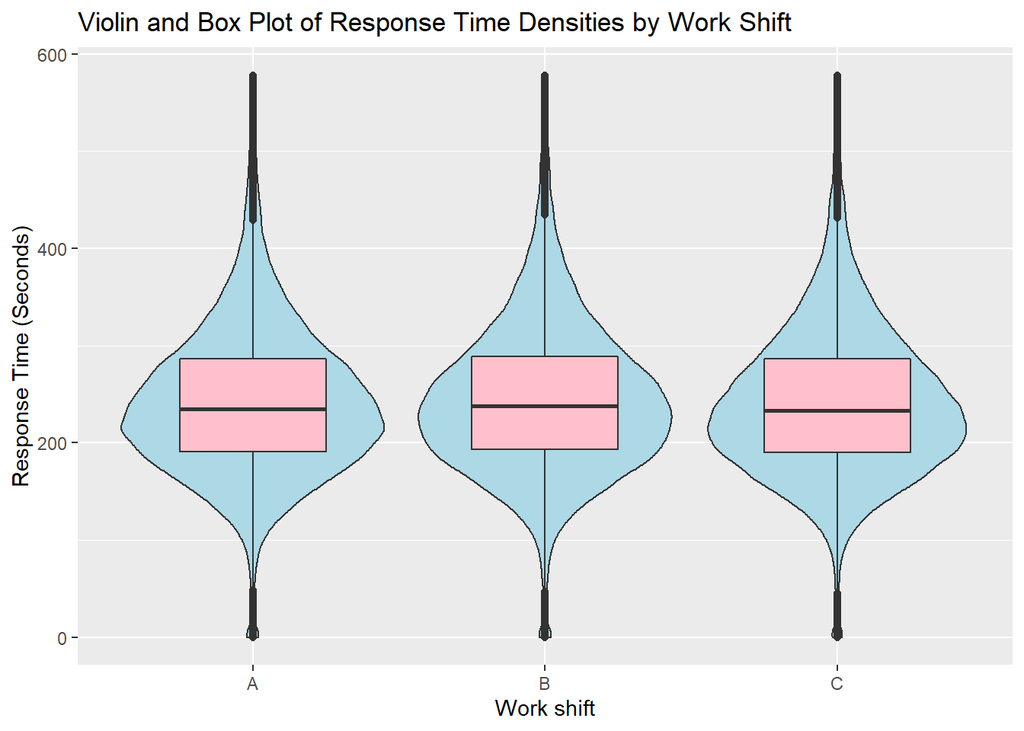

For this graph it can be seen that different work shifts did not affect the response time.

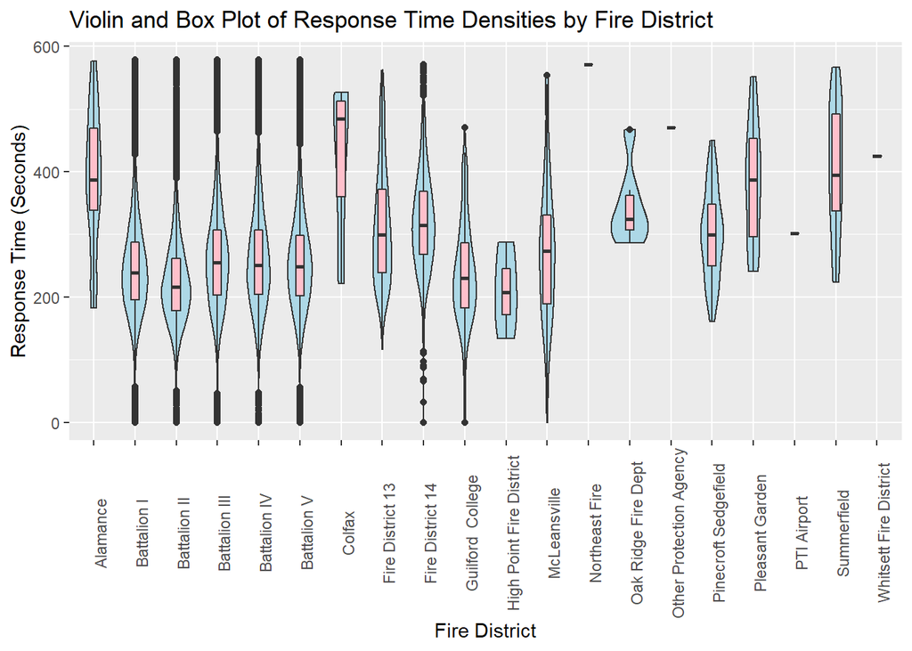

As shown by the graph, the response time varies depending on which fire district responded to the fire incident.

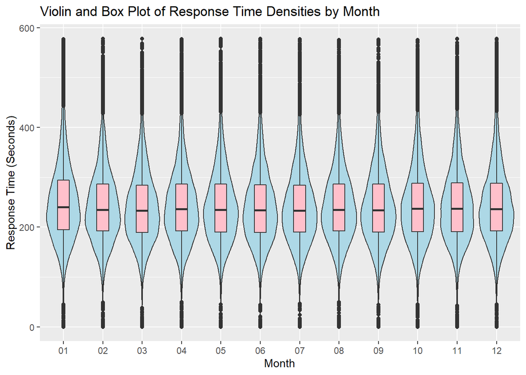

For this box and violin plot, we learned that the time of month in the year has very little effect on the response time.

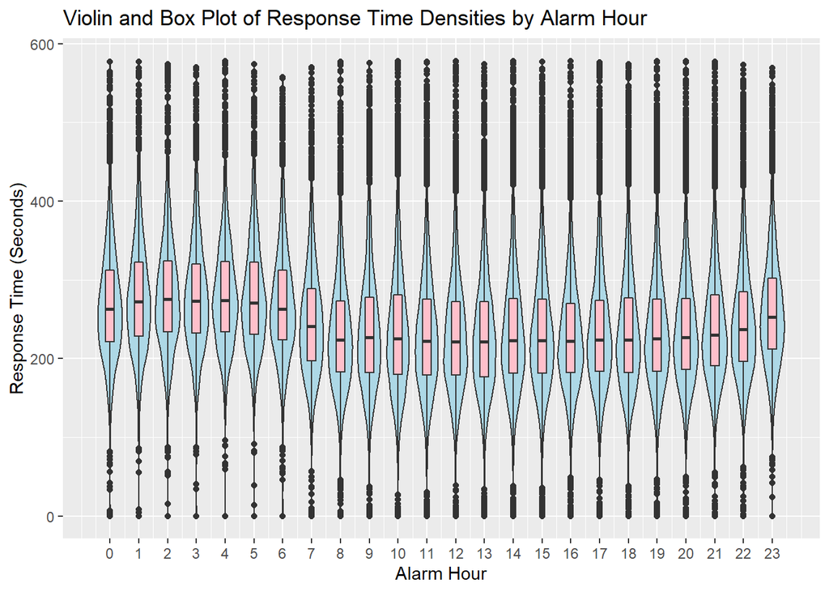

From this visual, we learned that alarm hour has a slight effect on response time, as shown by the dips in the plot.

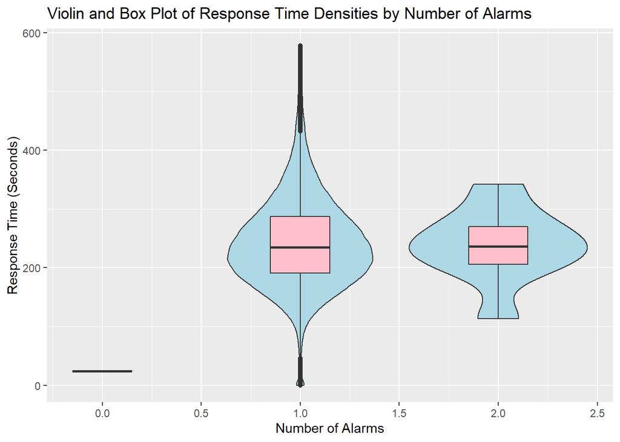

For the graph above, there would sometimes be a couple alarms set off for a fire incident, but it did not affect the response time whether the alarm was once or twice.

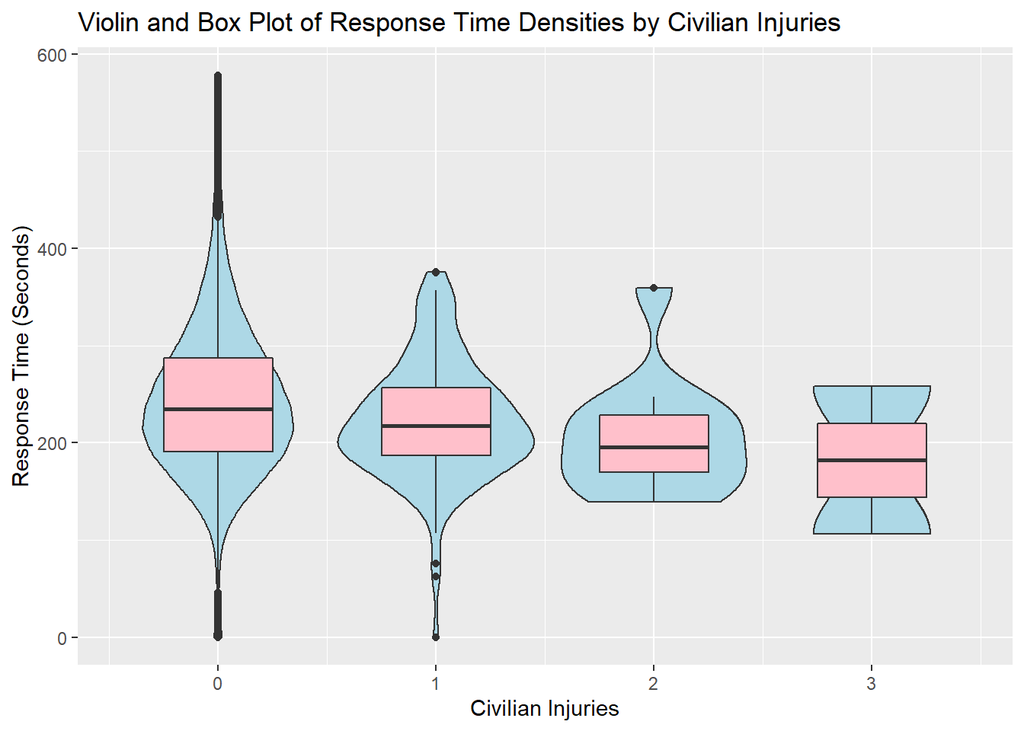

For the graph above, we can see the how each level of civilian injury various in relations to response time.

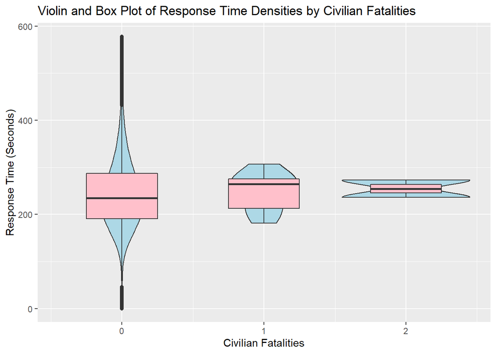

For the graph above, we can see the how each level of civilian fatality various in relations to response time.

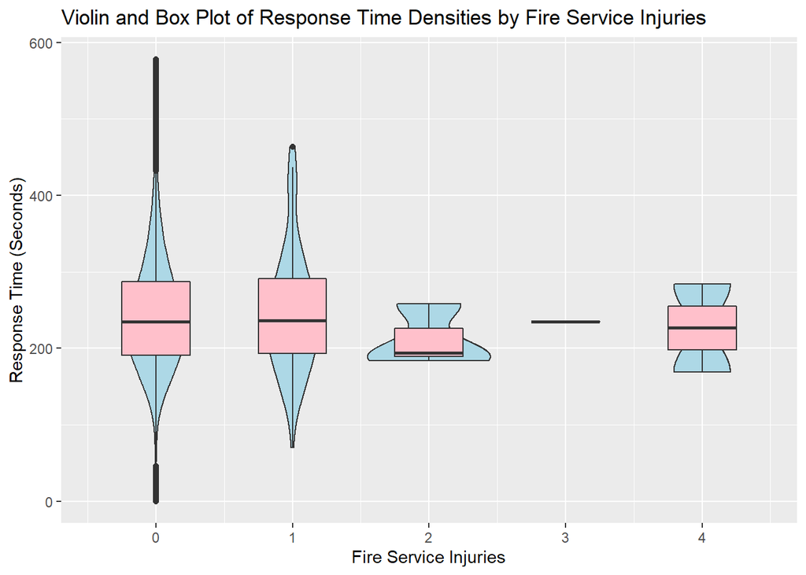

For the graph above, we can see the how each level of fire service injury various in relations to response time.